# HMKStat4DSII for Professor Tardella

# EXERCISE 2

### Provide the definition of an infinitely echangeable binary sequence of random variables X1, …, Xn, …..

A sequence of random variables $X_1,...,X_n,....$ is *exchangeable* if for any k-tuple $(n_1, ..,n_k)$ and any permutation $\sigma = (\sigma_1,...,\sigma_k)$ of the first k integers the following holds
$$(X_{n_1}, ..., X_{n_k})=(X_{\sigma_{n_1}}, ..., X_{\sigma_{n_k}})$$
*Infinitely Exchangeability* presents when the sequence of random variable is infinite and so the exchangeability hold infinitely for every subset of the sequence.
In case the sequence is binary (there are only 2 possible values for each variables), in case it satisfies the previous requirements, it’s said *an infinitely echangeable binary sequence of random variables*.

#### a

1. Given that the variables $X_i$ are binary we can model them as a bernoulli and use extensively De Finetti Theorem. So being $E[X_i]=\sum_i x_ip(x) =xDeFinetti= 1*\int_{[0.1]}\theta\pi(\theta)d\theta+0*\int_{[0.1]}(1-\theta)\pi(\theta)d\theta= E_\theta[\pi]$.
2. $E[X_iX_j]=\sum_i\sum_jx_ix_jj(x_i,x_j)=1*j(x_i=success, x_j=success)=\int_{[0,1]}\theta^2(1-\theta)^0\pi(\theta)d\theta=E_\pi[\theta^2]$
3. From what I saw in 1) and 2): $Cov[X_iX_j]=E[X_iX_j]-E[X_i]E[X_j]=E_\pi[\theta^2]-E_\pi[\theta]^2=Var_\pi[\theta]$

#### b

1. Being true that $Cov[X_iX_j]=Var_\pi[\theta]$, the variance is a non-negative function, so being positive implies that any couple of random variabes in that sequence must be non-negatively correlated.

#### c

1. We have that $Cor[X_i,X_j] = \frac{Cov[X_i,X_j]}{\sigma_{X_i}\sigma_{X_j}}=1$ $\rightarrow$ $Var_\pi[\theta]=Var[X]=$from 1) and 2) and what said before $=E_\pi[\theta](1-E_\pi[\theta])$ $\rightarrow$ $E_\pi[\theta^2]-E_\pi[\theta]^2 = E_\pi[\theta] - E_\pi[\theta]^2$ $\rightarrow$ $E_\pi[\theta^2]=E_\pi[\theta]$.

#### d

1. The condition $E_\pi[\theta^2]=E_\pi[\theta]$ $\rightarrow$ $\int_{[0,1]}\theta^2\pi(\theta)d\theta =\int_{[0,1]}\theta\pi(\theta)d\theta$.  
   So the $\pi$ distribution must be *discrete* since the function inside the integral share the relation $A=\theta k = k = B,\; k\neq 0$,so the integral is equal to 0. for the shape there is not a definite one, an example can be a bernoulli such that $\theta = 1 \iff Probability = 1, \theta \neq 1 \iff Probability = 0$, but substantially any discrete probability will suffice because integrals do not feel the outliers discrete points that have mass, so the equality at the start will hold and will always be of value zero.

# EXERCISE 3

Theorical Formulas and computations for this exercise can be found on the attached PDF *explanationEX3.pdf*.

```r
my_data <- read.table("dugong-data.txt", header = TRUE, row.names = NULL)
head(my_data)
```

```
##   I Length Age
## 1 1   1.80 1.0
## 2 2   1.85 1.5
## 3 3   1.87 1.5
## 4 4   1.77 1.5
## 5 5   2.02 2.5
## 6 6   2.27 4.0
```

```r
nrow(my_data)
```

```
## [1] 27
```

```r
ncol(my_data)
```

```
## [1] 3
```

#### 3a)

So we have this Dugong data consisting of 27 rows and 3 columns (Index, Length, Age). To study it we are considering a non linear regression moded of which I will describe the variables in the following. From now on Y_i are the Lengths of the Dugongs and Y_i is modeled by a normal distribution $Y_i \sim N(m_i, t^2)$, where $\mu_i = f(x_i) = \alpha - \beta\gamma^{(x_i)}$.  
To develop a model we have to make assumptions so here is assumed $\alpha \sim N(0, \sigma_\alpha^2)$  
$\beta \sim N(0, \sigma_\beta^2)$  
$\gamma \sim Unif(0,1)$  
$\tau^2 \sim IG(a,b)$.  
From this we have then that $\alpha \in \Re, \; \beta \in \Re,\; \gamma \in (0,1), \; \tau^2 \in (0,\inf)$.

#### 3b)

One of the main objective of the analysis is to find the Posterior distribution $\pi(x|Y)$, to achieve this not only we would need the prior (merely the product of the distributions quoted above), but also the object of this 3b) that is the *Likelihood*.  
Let’s compute the Likelihood, or better $\pi(Y|x)$.  
Given that we assume x fixed, and given the assumption is just a matter of fixing x_i inside the normal so $\pi(Y_i|x_i) \sim N(\alpha - \beta\gamma^{(x)}, \tau^2)$ so $Likelihood=\frac{1}{(2\tau^2)}^{|Y|/2}\exp{-(\sum (y_i - alpha + \beta\gamma^{(x)})^2/2\tau^2)}$

#### 3c)

```r
library(stats4)
library(graphics)


#x_i are the ages
my_data <- read.table("dugong-data.txt", header = TRUE, row.names = NULL)
x_i = my_data['Age']

Likelihood <- function(my_data = my_data, interesting){
  alpha <- interesting[1]
  beta <- interesting[2]
  tau2 <- interesting[3]
  gamma <- interesting[4]
  Y <- my_data[,2]
  x <- my_data[,3]

 1/(2*tau2*pi)^(length(Y)/2)*exp(-sum(Y-alpha+beta*gamma^x)^2/(2*tau2))}


Mle = optim(par = c(1,1,1,1), my_data = my_data, fn = Likelihood,  gr = NULL,
      method = "SANN")#,

prior <- function(my_data, interesting) {
  alpha <- interesting[1]
  beta <- interesting[2]
  tau2 <- interesting[3]
  gamma <- interesting[4]
  s_a2 <- 1
  s_b2 <- 4
    a <-1
    b <-1

    N1 <- (1/(2*pi*s_a2)^(1/2))*exp(-alpha^2/2*s_a2)
    N2 <- (1/(2*pi*s_b2)^(1/2))*exp(-beta^2/2*s_b2)
    GAmma <- (b^a/gamma(a))*(tau2^(-a-1))*exp(-b/tau2)
    if(gamma > 0 | gamma <= 1){
        return(N1*N2*GAmma)}
    else {
      return(0)
    }

}

Posterior <- function(my_data = my_data, interesting){
  alpha <- interesting[1]
  beta <- interesting[2]
  tau2 <- interesting[3]
  gamma <- interesting[4]
  Y <- my_data[,2]
  x <- my_data[,3]
  return(Likelihood(my_data, interesting)*prior(my_data,interesting))
}
MaP = optim(par = c(1,1,1,1), my_data = my_data, fn = Posterior,  gr=NULL,  method = "SANN")#,
cat('Maximum Likelihood Estimator')
```

```
## Maximum Likelihood Estimator
```

```r
print(Mle)
```

```
## $par
## [1]   1.2922805 -18.0374747   6.0395308   0.8456818
##
## $value
## [1] 0
##
## $counts
## function gradient
##    10000       NA
##
## $convergence
## [1] 0
##
## $message
## NULL
```

```r
cat('Maximum a Posteriori' )
```

```
## Maximum a Posteriori
```

```r
print(MaP)
```

```
## $par
## [1] -1.382791  2.531222  5.350535 17.466047
##
## $value
## [1] 0
##
## $counts
## function gradient
##    10000       NA
##
## $convergence
## [1] 0
##
## $message
## NULL
```

```r
#As we see parameters choices, makes the comparison pretty though and we see no similarity between the two.
```

#### 3d)

Prior = product of the priors = $\pi(\alpha, \beta, \gamma, \tau^2)=\frac{1}{\sqrt(2\pi\sigma_{\alpha}^2)}\exp{-\frac{\alpha^2}{2\sigma_{\alpha}^2}}\frac{1}{\sqrt(2\pi\sigma_{\beta}^2)}\exp{-\frac{\beta^2}{2\sigma_{\beta}^2}I_{\gamma \in[0,1]}}\frac{b^a}{\Gamma(a)}\tau^{2({-a-1})}\exp{\frac{-b}{\tau^2}}$

The hypermarameters I chose are $\sigma_{\alpha} = 0.4$, $\sigma_{\beta} = 10$ and $a =1, b = 2$. So  
$\alpha \sim N(0, 0.16)$  
$\beta \sim N(0, 100)$  
$\tau^2 \sim IG(1,2)$.  
Those parameters are chose to optimize the distirbutions in 3l) and 3m) and obtain a model that is very near the Dug data, indeed when in the end I will get some distributions for the DUg of age x, I will obtain all distributions very near to the data, in fact the mean of those normals will be very close to the mean of the data column of Length and the real average, indeed the average lenght of a Dugong is 2.6(the data were too poor obtained 2.33), I obtained 2.55 and I was satisfact.

#### 3e)

Having the Likelihood as $Likelihood=\frac{1}{(2\tau^2)}^{|Y|/2}\exp{-(\sum (y_i - alpha + \beta\gamma^{(x)})^2/2\tau^2)}$ and the Prior as $\pi(\alpha, \beta, \gamma, \tau^2)=\frac{1}{\sqrt(2\pi\sigma_{\alpha}^2)}\exp{-\frac{\alpha^2}{2\sigma_{\alpha}^2}}\frac{1}{\sqrt(2\pi\sigma_{\beta}^2)}\exp{-\frac{\beta^2}{2\sigma_{\beta}^2}I_{\gamma \in[0,1]}}\frac{b^a}{\Gamma(a)}\tau^{2({-a-1})}\exp{\frac{-b}{\tau^2}}$, we know that $Posterior \sim Prior*Likelihoo$, so computing the product with the fixed hyperparameters of 3d), and discarding every constant(e.g. $\frac{1}{\sqrt(2\pi\sigma_{\alpha}^2)}$), the final form of the Posterior probability is: $Posterior(\alpha, \beta, \gamma, \tau^2|Y) \sim\frac{1}{(\tau^2)^{|Y|/2}}\tau^{2(-a-1)}\exp({-\sum(y_i-\alpha+\beta\gamma^{x_i})^2/2\tau^2 - \alpha^2/2\sigma_\alpha - \beta^2/2\sigma_\beta - b/\tau^2})I_{[\gamma \in [0,1]]}$

#### 3f)

```r
library('invgamma')
set.seed(123)
nsim = 10000 #simulions
#lets remember
#The hypermarameters I chose are $\sigma_{\alpha} = 1$, $\sigma_{\beta} #= 2$ and $a = b = 1$'''
sigma_a2 <- 0.4 #
sigma_b2 <- 10#
a <-1
b <- 2
#for initialize the parameters
#series of Functions for the mean and Sd of every single Normal or shape #and rate





'for alpha full cd'
```

```
## [1] "for alpha full cd"
```

```r
mu_alpha <- function(beta, sigma_a2, tau2, gamma,  Y = my_data[,2], x = my_data[,3]){
  num = (2*(sigma_a2^2)*sum(Y)+ 2*(sigma_a2^2)*beta*sum(gamma^x))
  den = length(Y)*sigma_a2^2 + tau2
  return(num/den)
}
sigma_alpha <- function(beta, sigma_a2, tau2, gamma,  Y = my_data[,2], x = my_data[,3]){
  num = tau2*sigma_a2
  den = length(Y)*sigma_a2^2 + tau2
  return((num/den)^2)
}




'for beta full cd'
```

```
## [1] "for beta full cd"
```

```r
mu_beta <- function(alpha, sigma_b2, tau2, gamma,  Y = my_data[,2], x = my_data[,3]){
  num = 2*sigma_b2*sum(Y*gamma^x)-2*sigma_b2*alpha*sum(gamma^x)
  den = sigma_b2*sum(gamma^(2*x))+tau2
  return(num/den)
}

sigma_beta <- function(alpha, sigma_b2, tau2, gamma,  Y = my_data[,2], x = my_data[,3]){
  num = sigma_b2*tau2
  den = sigma_b2*sum(gamma^(2*x))+tau2
  return((num/den)^2)
}



'Gamma is unknown so is not here will be implemented with metropolis'
```

```
## [1] "Gamma is unknown so is not here will be implemented with metropolis"
```

```r
TheGammaDis <- function(beta, gamma, alpha, Y = my_data[,2], tau2,  x = my_data[,3]){

  if((gamma <=1)&(gamma >=0)) {
    #for reason of overflow, after a little analysis i decided that thins function will only return the exponent
    #then I will do e^a/e^b = e^(a-b)
    #with result that usually a and b are similar in size so no overflow will ever happen again
    #I could have scaled the log but this method works and is fine for me
    num = (-sum(beta^(2)*gamma^(2*x)-2*alpha*beta*gamma^x+2*Y*beta*gamma^x)/(2*tau2))

}
  else {
    num = 0
  }
  return(num)
}



'tau^2 full cd'
```

```
## [1] "tau^2 full cd"
```

```r
shape_tau2 <- function(alpha, Y = my_data[,2]){
  num = length(Y)/2 + alpha
  return(num)
}
rate_tau2 <- function(alpha, gamma, beta,  Y = my_data[,2], x = my_data[,3], b){
  num = (sum((Y-alpha+beta*gamma^x)^2)+2*b)/2
  return(num)
}

gibbs_normGauMet_cycle <-function(nsim, alphastart,
                                  betastart, gammastart, tau2start){
  #empty vectors
  alphasim <- rep(NA,nsim+1)
  betasim <- rep(NA,nsim+1)
  gammasim <- rep(NA,nsim+1)
  tau2sim <- rep(NA,nsim+1)
  #initialization at t = 1
  alphasim[1] <- alphastart
  betasim[1]  <- betastart
  gammasim[1] <- gammastart
  tau2sim[1]  <- tau2start

  for(t in 1:nsim){
    #parameters_alphaNormal
    mean_alpha <- mu_alpha(betasim[t], sigma_a2, tau2sim[t],
                           gammasim[t], my_data[,2], my_data[,3])
    sd_alpha <- sigma_alpha(betasim[t], sigma_a2, tau2sim[t],
                            gammasim[t],my_data[,2], my_data[,3])

    alphasim[t+1]<-rnorm(1,mean=mean_alpha,sd=sd_alpha)

    #parameters_betaNormal

    mean_beta <- mu_beta(alphasim[t+1], sigma_b2, tau2sim[t],
                         gammasim[t], my_data[,2], my_data[,3])
    sd_beta <- sigma_beta(alphasim[t+1], sigma_b2, tau2sim[t],
                          gammasim[t], my_data[,2],my_data[,3])

    betasim[t+1]<-rnorm(1, mean=mean_beta, sd=sd_beta)

    #here metropolis for gammasim but only one draw at each step
    #gamma takes values in [0,1] so the proposal will be the unif([0,1])


    #This part is if you dfo metropolis on first trial and not with 100 simuklations
###    z <- gammasim[t]
###    gammaprop <- runif(1,0,1)

###    inside <- c(exp(TheGammaDis(betasim[t+1],gammaprop,alphasim[t+1], my_data[,2],tau2sim[t], ###my_data[,3])-TheGammaDis(betasim[t+1], z,alphasim[t+1],my_data[,2],tau2sim[t],  my_data[,3] )), 1)
    #i did the subtraction to try to scale the exponential to avoid to get some 0 that would #result in Nan
###    ACCEPT <- (log(gammaprop) < log(min(inside)))

###    gammasim[t+1] <- ifelse(ACCEPT, gammaprop, z)
  #  cat('gammasim', gammasim[t+1])

    z <- gammasim[t]
    ## draw a candidate for the next/future state of the
    #chain at time(t)
    #Here i do 100 simulations and take average since only 1 point seems erroneous
    met_vec <- rep(NA,100)
    met_vec[1] <- z
    for(j in 1:100){

    gammaprop <- runif(1,0,1)
    inside <- c(exp(TheGammaDis(betasim[t+1],gammaprop,alphasim[t+1], my_data[,2],tau2sim[t], my_data[,3])-TheGammaDis(betasim[t+1], met_vec[j],alphasim[t+1],my_data[,2],tau2sim[t],  my_data[,3] )), 1)
    #i did the subtraction to try to scale the exponential to avoid to get some 0 that would #result in Nan
    ACCEPT <- (log(gammaprop) < log(min(inside)))
    met_vec[j+1] <- ifelse(ACCEPT, gammaprop, z)
    }
    gammasim[t+1] <- mean(met_vec)

    shapetau2 <- shape_tau2(alphasim[t+1], my_data[,2])
    ratetau2 <- rate_tau2(alphasim[t+1], gammasim[t+1], betasim[t+1],
                            my_data[,2], my_data[,3], b)
    tau2sim[t+1] <- rinvgamma(1, shapetau2, ratetau2)
   # cat('tell me where4')
 #   print('alibaba')
  #  print(alphasim[c(1:t+1)])
   # print(betasim[c(1:t+1)])
 #   print(gammasim[c(1:t+1)])
    #print(gammasim[t+1])
  # # print('tau')
  #  print(tau2sim[c(1:t+1)])
  #  print('e i 40 ladroni di NA')
  #prints proof of a long debugging for god's sake

    }
  gibbssample<-cbind(alphasim, betasim, gammasim, tau2sim)
  return(gibbssample)
}
#my starting points are realistic points in thos distributions and seem to work properly
my_gibbs <- gibbs_normGauMet_cycle(10000, 1,
                                  2, 0.5, 1)
head(my_gibbs)
```

```
##       alphasim   betasim  gammasim   tau2sim
## [1,] 1.0000000   2.00000 0.5000000  1.000000
## [2,] 4.0140883 -10.97788 0.3923348  5.468642
## [3,] 1.6177500 -38.76513 0.3383185 14.594714
## [4,] 0.2395596 -26.27317 0.2738513  6.581779
## [5,] 1.2386819  37.73110 0.2442790  6.960281
## [6,] 2.4569332  81.58090 0.2123520 12.793045
```

#### 3g)

Here follows the Trace-plots of the variables.

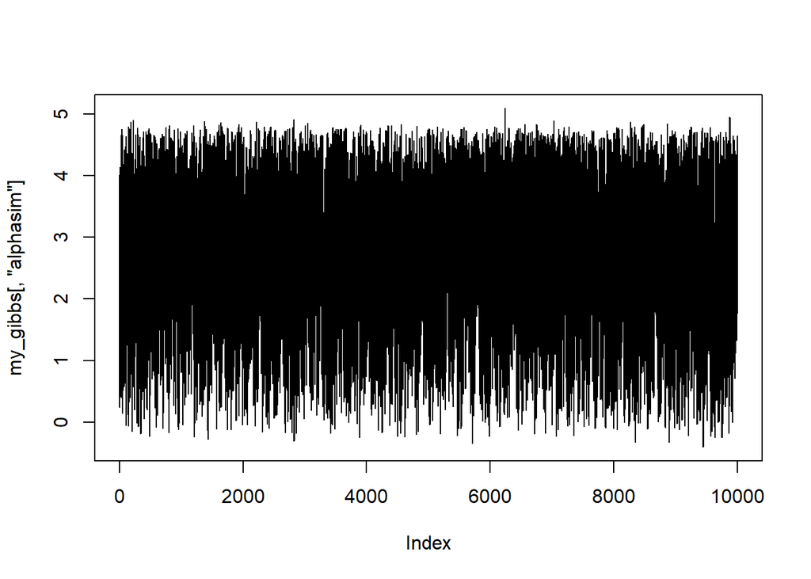

```r
plot(my_gibbs[,'alphasim'], type="l")
```

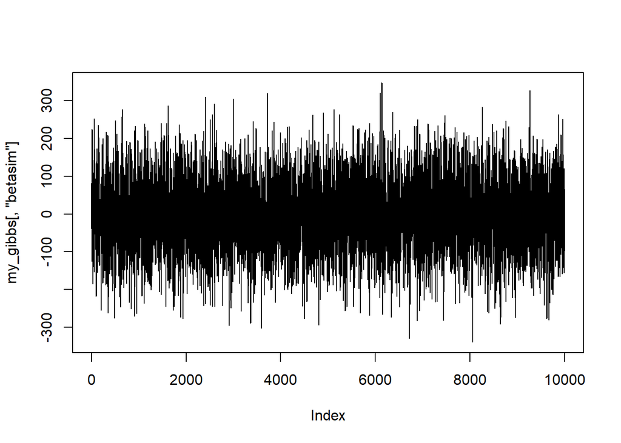

```r
plot(my_gibbs[,'betasim'], type="l")
```

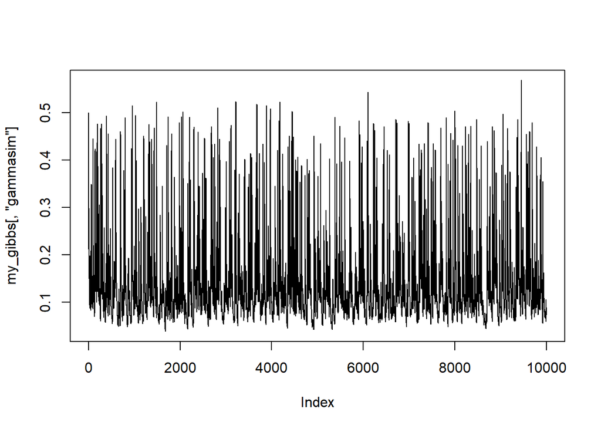

```r
plot(my_gibbs[,'gammasim'], type="l")
```

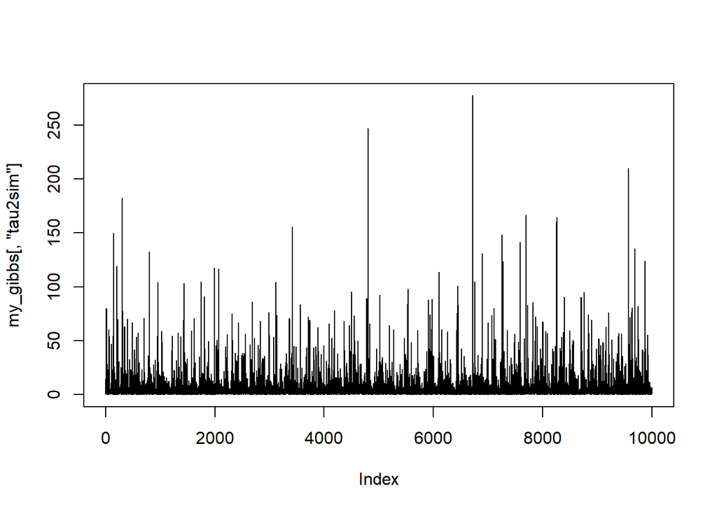

```r
plot(my_gibbs[,'tau2sim'], type="l")
```

#### 3h)

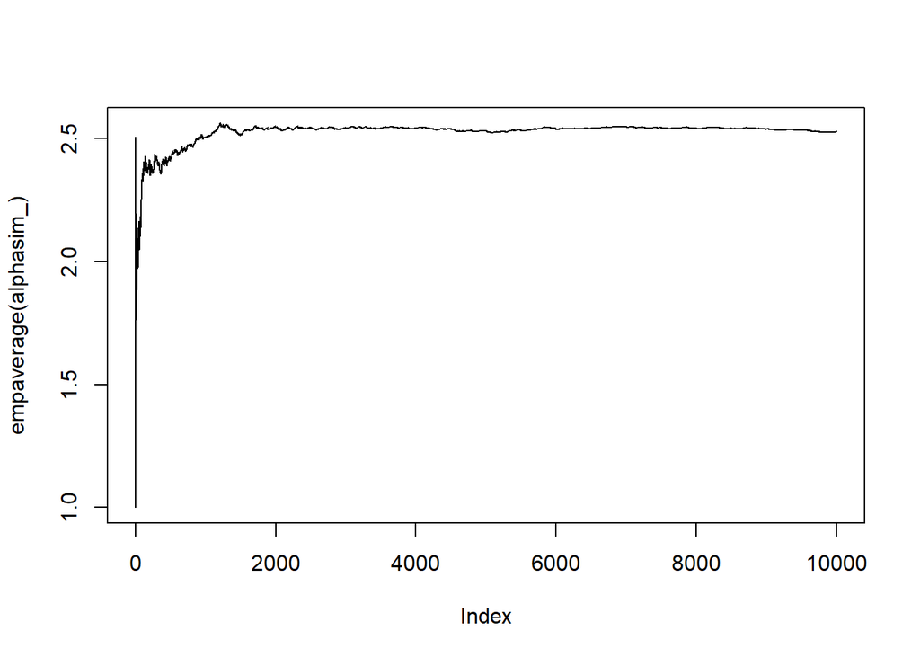

```r
alphasim_ = my_gibbs[,'alphasim']
betasim_ = my_gibbs[,'betasim']
gammasim_ = my_gibbs[,'gammasim']
tau2sim_ = my_gibbs[,'tau2sim']
empaverage <- function(lis ){
  index_arrive = length(lis)
  vec <- c()
  for(i in 1 : index_arrive){
  vec <- c(vec, mean(lis[c(1:i)]))}
  return(vec)
}

plot(empaverage( alphasim_), type = 'l')
```

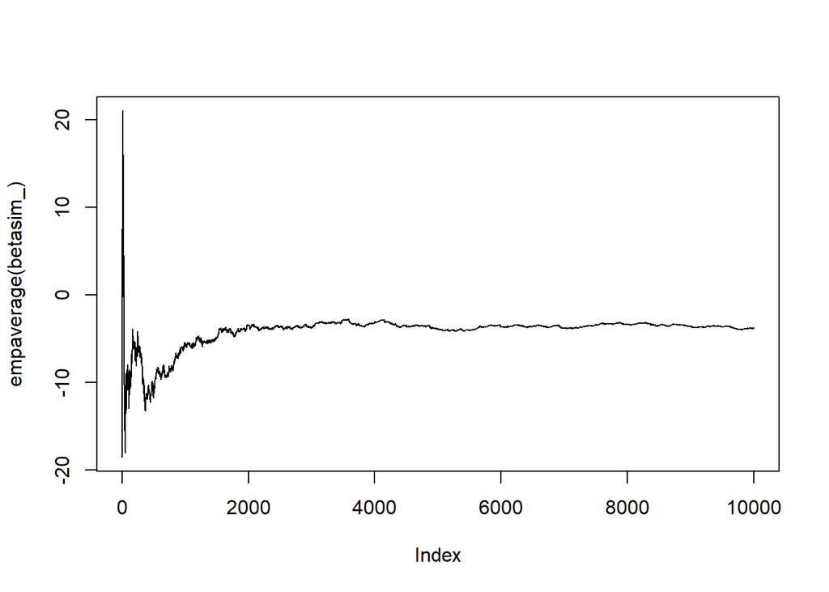

```r
plot(empaverage(betasim_), type = 'l')
```

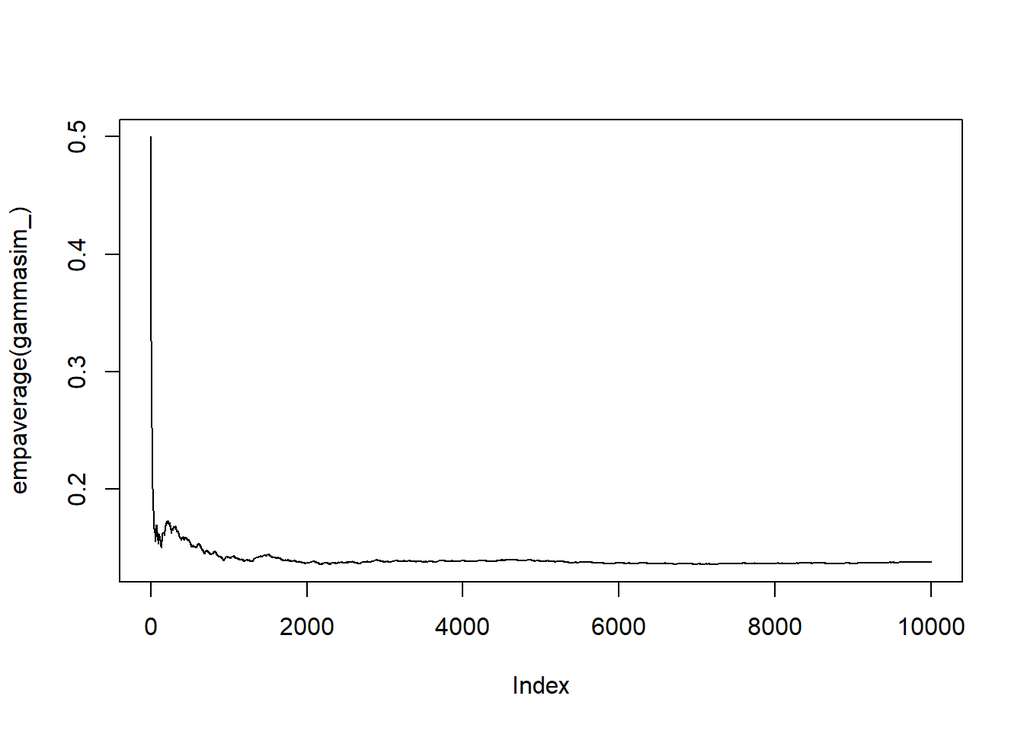

```r
plot(empaverage(gammasim_), type = 'l')
```

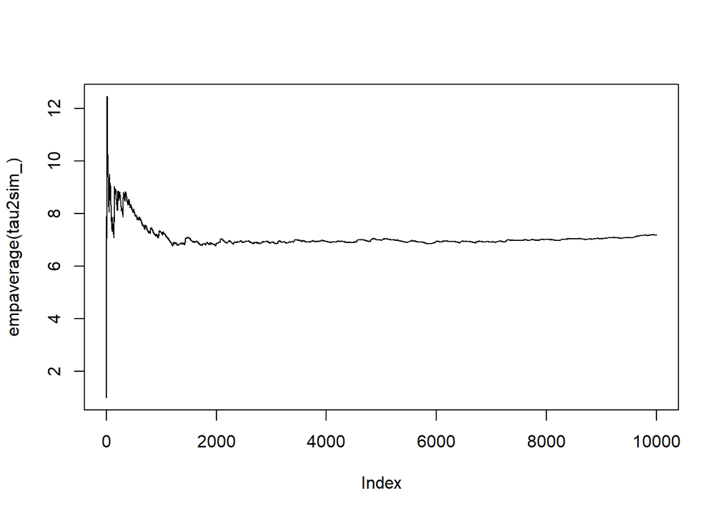

```r
plot(empaverage(tau2sim_), type = 'l')
```

As we saw at lessons we could discard the first simulations, since there is usually a certain time before the distribution start stabilizing.

#### 3i)

```r
#Code for alphasim
library(LaplacesDemon)
approx_alpha <- mean(my_gibbs[, 'alphasim'])
cat('Approx Alpha', approx_alpha)
```

```
## Approx Alpha 2.527625
```

```r
ESS <- ESS(my_gibbs[, 'alphasim'])
cat('\nESS', ESS)
```

```
##
## ESS 5242.249
```

```r
#or alternatively
```

```r
#Code for alphasim
library(coda)
approx_beta <- mean(my_gibbs[, 'betasim'])
cat('Approx Beta', approx_beta)
```

```
## Approx Beta -3.80378
```

```r
ESS <-ESS(my_gibbs[, 'betasim'])
cat('\nESS', ESS)
```

```
##
## ESS 10001
```

```r
library(coda)
approx_gamma <- mean(my_gibbs[, 'gammasim'])
cat('Approx Gamma', approx_gamma)
```

```
## Approx Gamma 0.1379019
```

```r
ESS <-ESS(my_gibbs[, 'gammasim'])
cat('\nESS', ESS)
```

```
##
## ESS 1038.105
```

```r
approx_tau2 <- mean(my_gibbs[, 'tau2sim'])
cat('Approx Tau^2', approx_tau2)
```

```
## Approx Tau^2 7.172643
```

```r
ESS <- ESS(my_gibbs[, 'tau2sim'])
cat('\nESS', ESS)
```

```
##
## ESS 4252.519
```

```r
'For the ESS I could also have done '
```

```
## [1] "For the ESS I could also have done "
```

```r
ESS(my_gibbs)
```

```
##  alphasim   betasim  gammasim   tau2sim
##  5242.249 10001.000  1038.105  4252.519
```

Is pretty clear that $\beta$ is converging pretty well, while $\alpha, \gamma, \tau^2$ seem to have some more problems in convergence and even excluding some initial values it keeps still at half the dimension of the data.

#### 3j)

I estimated the Posterior UNcertainty using the HPD interval in the p.interval function.  
The worst parameter will be the one with the largest interval, meaning the values are quite sparse.

The HPD (highest posterior density) interval is identical to the quantile-based probability interval when the posterior probability distribution is unimodal and symmetric. Otherwise, the HPD interval is the smallest interval, because it is estimated as the interval that contains the highest posterior density. Unlike the quantile-based probability interval, the HPD interval could be one-tailed or two-tailed, whichever is more appropriate.

```r
alphaCI <- p.interval(my_gibbs[,'alphasim'], HPD=TRUE, MM=FALSE, prob=0.95)
betaCI <- p.interval(my_gibbs[,'betasim'], HPD=TRUE, MM=TRUE, prob=0.95)
gammaCI <- p.interval(my_gibbs[,'gammasim'], HPD=TRUE, MM=TRUE, prob=0.95)
tau2CI <- p.interval(my_gibbs[,'tau2sim'], HPD=TRUE, MM=TRUE, prob=0.95)
print(p.interval(my_gibbs, HPD=TRUE, MM=FALSE, prob=0.95))
```

```
##                  Lower       Upper
## alphasim    0.39009257   4.7825121
## betasim  -172.18955314 173.4509836
## gammasim    0.04167957   0.3054862
## tau2sim     0.08885952  26.0674430
## attr(,"Probability.Interval")
## [1] 0.950005
```

```r
print('alphaCI \n')
```

```
## [1] "alphaCI \n"
```

```r
print('\n width \n')
```

```
## [1] "\n width \n"
```

```r
print(abs(alphaCI[2]-alphaCI[1]))
```

```
## [1] 4.39242
```

```r
print('betaCI \n')
```

```
## [1] "betaCI \n"
```

```r
print('\n width \n')
```

```
## [1] "\n width \n"
```

```r
print(abs(betaCI[2]-betaCI[1]))
```

```
## [1] 345.6405
```

```r
print('gammaCI \n')
```

```
## [1] "gammaCI \n"
```

```r
print('\n width \n')
```

```
## [1] "\n width \n"
```

```r
print(abs(gammaCI[2]-gammaCI[1]))
```

```
## [1] 0.2638066
```

```r
print('tau2CI \n')
```

```
## [1] "tau2CI \n"
```

```r
print('\n width \n')
```

```
## [1] "\n width \n"
```

```r
print(abs(tau2CI[2]-tau2CI[1]))
```

```
## [1] 25.97858
```

```r
#The most uncertain is beta
#it remains it even if I discard the first 1000 samples every time!
```

The most uncertain is $\beta$ with $ICwidth\sim 345$ since the credibility interval is the largest, it means values are more sparse and not concentrated, maybe if I exclude the first values it would be different since beta oscillates a lot at start.

Let’s see

```r
alphaCI <- p.interval(my_gibbs[2000:10000,'alphasim'], HPD=TRUE, MM=FALSE, prob=0.95)
betaCI <- p.interval(my_gibbs[2000:10000,'betasim'], HPD=TRUE, MM=TRUE, prob=0.95)
gammaCI <- p.interval(my_gibbs[2000:10000,'gammasim'], HPD=TRUE, MM=TRUE, prob=0.95)
tau2CI <- p.interval(my_gibbs[2000:10000,'tau2sim'], HPD=TRUE, MM=TRUE, prob=0.95)
print(p.interval(my_gibbs, HPD=TRUE, MM=FALSE, prob=0.95))
```

```
##                  Lower       Upper
## alphasim    0.39009257   4.7825121
## betasim  -172.18955314 173.4509836
## gammasim    0.04167957   0.3054862
## tau2sim     0.08885952  26.0674430
## attr(,"Probability.Interval")
## [1] 0.950005
```

```r
print('alphaCI \n')
```

```
## [1] "alphaCI \n"
```

```r
print('\n width \n')
```

```
## [1] "\n width \n"
```

```r
print(abs(alphaCI[2]-alphaCI[1]))
```

```
## [1] 4.408074
```

```r
print('betaCI \n')
```

```
## [1] "betaCI \n"
```

```r
print('\n width \n')
```

```
## [1] "\n width \n"
```

```r
print(abs(betaCI[2]-betaCI[1]))
```

```
## [1] 342.5312
```

```r
print('gammaCI \n')
```

```
## [1] "gammaCI \n"
```

```r
print('\n width \n')
```

```
## [1] "\n width \n"
```

```r
print(abs(gammaCI[2]-gammaCI[1]))
```

```
## [1] 0.2609721
```

```r
print('tau2CI \n')
```

```
## [1] "tau2CI \n"
```

```r
print('\n width \n')
```

```
## [1] "\n width \n"
```

```r
print(abs(tau2CI[2]-tau2CI[1]))
```

```
## [1] 26.50442
```

```r
#The most uncertain is beta
#it remains it even if I discard the first 1000 samples every time!
```

Indeed almost the same!